# Supplementary code to ‘Misidentification errors in reencounters result in biased estimates of survival from CJS models: evidence and a possible solution using the robust design’ by E. Rakhimberdiev et al., Methods in Ecology and Evolution, submitted

*code by Eldar Rakhimberdiev*

You might enjoy [html version of this supplementary](http://htmlpreview.github.io/?https://raw.githubusercontent.com/eldarrak/RDM-capture-reencounter-with-misidentification/master/code/All_code.html).

## 0. Set up output and run options

```r
set.seed(123)
```

### 0.1 To run or to download?

Parts of this code take time to run, so if you want to go through examples fast and do not want to install all the software

```r
Run_everything=FALSE # Change to TRUE if you want run all the models on your side
```

### 0.2 Online or local data?

This script can operate with online or local data. If `Use_local_data` set to TRUE working directory expected to have folder `data`. If `Run_everything` set to TRUE `results` directory will be created and all results will be saved there.

```r
Use_local_data=FALSE # Change to TRUE if you want to use local data and to not download them from the GitHub page.
```

### 0.3 Checks and downloads

```r
library(httr)
library(tidyverse)
if (Use_local_data) {
   if (!'results' %in% list.dirs(full.names=FALSE, recursive=FALSE)) {
       if (Run_everything) {
          dir.create('results')
       } else {
          stop('results directory not found!')
       }
   }
   if (!'data' %in% list.dirs(full.names=FALSE, recursive=FALSE)) stop('data directory not found!')
} else {
   if (!'results' %in% list.dirs(full.names=FALSE, recursive=FALSE)) dir.create('results')
   # we will now download all the result files
   Result_req <- GET("https://api.github.com/repos/eldarrak/RDM-capture-reencounter-with-misidentification/contents/results")
   Results_files <- unlist(lapply(content(Result_req), "[", "name"), use.names = F)
   Results_dir<-'https://github.com/eldarrak/CJS-with-misidentification/blob/master/results/'
   for (i in 1:length(Results_files)) {
      Filename<-Results_files[i]
      download.file(paste0(Results_dir, Filename, '?raw=true'),
        destfile=paste0('./results/', Filename), mode='wb')
   }
  }
if (Use_local_data & !'data' %in% list.dirs(full.names=FALSE, recursive=FALSE)) {
    stop('data directory not found')
}
```

### 0.4 load libraries and source functions

We need `jagsUI` to run jags code. Note that to run the models you will also have to install jags software (Plummer 2011) from [here](http://mcmc-jags.sourceforge.net).

```r
library('jagsUI')
```

Now we source helper functions

```r
# general functions
source('https://git.io/fhhtZ')
```

```
## sourcing functions...
## simul.cjs.multiple.sightings()   Done
## known.state.cjs()   Done
## cjs.init.z()   Done
## known.state.cjs.mult()   Done
## get.first()   Done
## you are all set
```

## 1. Simulate and solve Phi_dot_P_dot_Theta_dot models

For this exersice we simulate data with the function `simul.cjs.multiple.sightings` and then with the function `run_c_c_c_models` estimate CJS, RDM and RDMa models over these data.

### 1.1 Define wrapper function to run simulations and run the models

```r
run_c_c_c_models<-function(CH, n.chains=6,  n.adapt=NULL, RHat_limit=1.1, max.iter=200000,
                           iter.increment=5000, models.to.run=c('CJS', 'RDM', 'RDMa')) {
  # this function runs Phi_dot_p_dot_Theta_dot models
  Res<-list(CH=CH)

  if ('CJS' %in% models.to.run) {
     cat('running CJS-c-c model')
     # flatten the data
     CH_flat<-apply(CH, c(1,2), sign)
     # Create vector with occasion of marking
     f <- apply(CH_flat, 1, get.first)
     Order<-(order(f))
     CH_flat<-CH_flat[Order,]
     f<-f[Order]
     # Specify model in BUGS language
     sink("cjs-c-c.jags")
     cat("
       model {
         # Priors and constraints
         for (i in 1:nind){
           for (t in f[i]:(n.occasions-1)){
             phi[i,t] <- mean.phi
             p[i,t] <- mean.p
           } #t
         } #i

         mean.phi ~ dunif(0, 1)         # Prior for mean survival
         mean.p ~ dunif(0, 1)           # Prior for mean recapture

         # Likelihood
         for (i in 1:nind){
           # Define latent state at first capture
           z[i,f[i]] <- 1
           for (t in (f[i]+1):n.occasions){
             # State process
             z[i,t] ~ dbern(mu1[i,t])
             mu1[i,t] <- phi[i,t-1] * z[i,t-1]
             # Observation process
             y[i,t] ~ dbern(mu2[i,t])
             mu2[i,t] <- p[i,t-1] * z[i,t]
           } #t
         } #i
      }
    ",fill = TRUE)
    sink()

    # Bundle data
    jags.data <- list(y = CH_flat, f = f, nind = dim(CH_flat)[1], n.occasions = dim(CH_flat)[2])

    inits <- function(){list(mean.phi=runif(1,0,1), mean.p = runif(1,0,1), z = known.state.cjs(CH_flat))}

    # Parameters monitored
    parameters <- c("mean.p", "mean.phi")

    # Call JAGS from R
    cjs.c.c <- autojags(jags.data, inits,
                       parameters, "cjs-c-c.jags", n.chains = n.chains,
                       parallel=TRUE,
                       Rhat.limit=RHat_limit, n.adapt=NULL,
                       max.iter=max.iter, iter.increment= iter.increment, save.all.iter=FALSE )
    cat('   Done!\n')
    Res$CJS<-cjs.c.c
  }
  if ('RDM' %in% models.to.run | 'RDMa' %in% models.to.run) {
    # Create vector with occasion of marking
    f <- apply(CH, 1, get.first)
    Order<-(order(f))
    CH<-CH[Order,]
    f<-f[Order]

    sightings_and_fresh<-colSums(CH) # count per year
    All.Years=data.frame(Years=1:dim(CH)[2], N_marked=0)
    Rle<-rle(apply(CH, 1, get.first))
    for (year in 1:length(Rle$lengths)) {
      All.Years$N_marked[Rle$values[year]]<-Rle$lengths[year]
    }

    N_marked<-  All.Years$N_marked
    N_reads<-sightings_and_fresh-N_marked
    N_reads<-N_reads[-1]
    sum_N_marks_used<-cumsum(All.Years$N_marked)

    # Bundle data
    jags.data <- list(y = CH, f = f, nind = dim(CH)[1],
                     n.occasions = dim(CH)[2],
                     sum_N_marks_used=sum_N_marks_used,
                     N_reads=N_reads, N_reads2=N_reads)

    inits <- function(){list(z = known.state.cjs.mult(CH),
                            mean.phi = runif(1, 0, 1),
                            mean.p = runif(1, 0, 1),
                            mean.theta=runif(1, 0, 1))}

    # Parameters monitored
    parameters <- c("mean.phi" , "mean.p", "mean.theta")
  }

   if ('RDM' %in% models.to.run) {
    # Specify model in BUGS language
    sink("RDM-c-c-c.jags")
    cat("
      model {
        # Priors and constraints
        for (i in 1:nind){
          for (t in f[i]:(n.occasions-1)){
             phi[i,t] <- mean.phi
             lambda_true[i,t]<-mean.lambda.true
          } #t
        } #i
        mean.phi ~ dunif(0, 1)         # Prior for mean survival
        mean.p ~ dunif(0, 1)           # Prior for mean recapture
        mean.lambda.true<- -log(1-mean.p)
        mean.theta ~ dunif(0,1)        # Prior for mean correct identification
        for (t in 1:(n.occasions-1)) {
          theta.t[t]<-mean.theta
        }

        # Likelihood
        for (i in 1:nind){
          # Define latent state at first capture
          z[i,f[i]] <- 1
          for (t in (f[i]+1):n.occasions){
            # State process
            z[i,t] ~ dbern(mu1[i,t])
            mu1[i,t] <- phi[i,t-1] * z[i,t-1]
            # Observation process
            lambda_obs[i,t-1]<- lambda_true[i,t-1]*z[i,t]*theta.t[t-1]+
                            Lambda_z_sum[t-1] -
                            lambda_true[i,t-1]*z[i,t]*(1-theta.t[t-1])/(sum_N_marks_used[t-1]-1)
          } #t
        } #i

        for (t in 1:(n.occasions-1)) {
        # here I add the total sum over all lambda_z
        Lambda_z_sum[t]<-sum(lambda_true[1:(sum_N_marks_used[t]),t]*
                   z[1:(sum_N_marks_used[t]),t+1])*
                   (1-theta.t[t])/(sum_N_marks_used[t]-1)
        # Below is the same but in RDMa model
        #Lambda_z_sum[t]<-N_reads2[t]*
        #     (1-theta.t[t])/(sum_N_marks_used[t]-1)
        Lambda_obs_sum[t]<-sum(lambda_obs[1:(sum_N_marks_used[t]),t])
        P_multin[1:(sum_N_marks_used[t]),t] <-
              lambda_obs[1:(sum_N_marks_used[t]),t]/
              ifelse(Lambda_obs_sum[t]==0, 1, Lambda_obs_sum[t])
        N_reads[t]~ dpois(Lambda_obs_sum[t])
        y[1:sum_N_marks_used[t],t+1] ~
              dmulti(P_multin[1:sum_N_marks_used[t],t],
              N_reads2[t])
        }
    }
    ",fill = TRUE)
    sink()

    # Call JAGS from R
    RDM.c.c.c <- autojags(jags.data, inits, parameters,
                       "RDM-c-c-c.jags", n.chains = n.chains,
                       parallel=TRUE,
                       Rhat.limit=RHat_limit, n.adapt=NULL,
                       max.iter=max.iter, iter.increment= iter.increment, save.all.iter=FALSE)
                       cat('   Done!\n')
    Res$RDM<-RDM.c.c.c
  }

  if ('RDMa' %in% models.to.run) {
    cat('running RDMa-c-c-c model')
    # Specify model in BUGS language
    sink("RDMa-c-c-c.jags")
    cat("
      model {
        # Priors and constraints
        for (i in 1:nind){
          for (t in f[i]:(n.occasions-1)){
             phi[i,t] <- mean.phi
             lambda_true[i,t]<-mean.lambda.true
          } #t
        } #i
        mean.phi ~ dunif(0, 1)         # Prior for mean survival
        mean.p ~ dunif(0, 1)           # Prior for mean recapture
        mean.lambda.true<- -log(1-mean.p)
        mean.theta ~ dunif(0,1)        # Prior for mean correct identification
        for (t in 1:(n.occasions-1)) {
          theta.t[t]<-mean.theta
        }

        # Likelihood
        for (i in 1:nind){
          # Define latent state at first capture
          z[i,f[i]] <- 1
          for (t in (f[i]+1):n.occasions){
            # State process
            z[i,t] ~ dbern(mu1[i,t])
            mu1[i,t] <- phi[i,t-1] * z[i,t-1]
            # Observation process
            lambda_obs[i,t-1]<- lambda_true[i,t-1]*z[i,t]*theta.t[t-1]+
                           Lambda_z_sum[t-1] -
                           lambda_true[i,t-1]*z[i,t]*(1-theta.t[t-1])/(sum_N_marks_used[t-1]-1)
          } #t
        } #i

        for (t in 1:(n.occasions-1)) {
        # here I add the total sum over all lambda_z
        #Lambda_z_sum[t]<-sum(lambda_true[1:(sum_N_marks_used[t]),t]*
        #           z[1:(sum_N_marks_used[t]),t+1])*
        #          (1-theta.t[t])/(sum_N_marks_used[t]-1)
        # above is the RDM model
        Lambda_z_sum[t]<-N_reads2[t]*
              (1-theta.t[t])/(sum_N_marks_used[t]-1)
        Lambda_obs_sum[t]<-sum(lambda_obs[1:(sum_N_marks_used[t]),t])
        P_multin[1:(sum_N_marks_used[t]),t] <-
              lambda_obs[1:(sum_N_marks_used[t]),t]/
              ifelse(Lambda_obs_sum[t]==0, 1, Lambda_obs_sum[t])
        N_reads[t]~ dpois(Lambda_obs_sum[t])
        y[1:sum_N_marks_used[t],t+1] ~
              dmulti(P_multin[1:sum_N_marks_used[t],t],
              N_reads2[t])
        }
    }
    ",fill = TRUE)
    sink()

    # Call JAGS from R
    RDMa.c.c.c <- autojags(jags.data, inits, parameters,
                       "RDMa-c-c-c.jags", n.chains = n.chains,
                       parallel=TRUE,
                       Rhat.limit=RHat_limit, n.adapt=NULL,
                       max.iter=max.iter, iter.increment= iter.increment, save.all.iter=FALSE)
                       cat('   Done!\n')
    Res$RDMa<-RDMa.c.c.c
   }
   return(Res)
}
```

### 1.2 Define parameters for a sample simulation (Phi=0.9, P=0.9, theta=0.95)

```r
n.occasions <- 5                       # Number of capture occasions
n.marked <- 15                         # Number marked each year
marked <- rep(n.marked, n.occasions-1) # Annual number of newly marked individuals

Phi_dot=0.9
P_dot=0.9
Theta_dot=0.95
RHat_limit=1.01
max.iter=20000
n.adapt=5000
iter.increment=4000
nRuns=5

phi <- rep(Phi_dot, n.occasions-1) # survival
p <- rep(P_dot, n.occasions-1)  # resighting
# Define matrices with survival recapture and correct identification
PHI <- matrix(phi, ncol = n.occasions-1, nrow = sum(marked))
P <- matrix(p, ncol = n.occasions-1, nrow = sum(marked))

theta<- rep(Theta_dot, n.occasions-1) # correctly identified
THETA<-matrix(theta, ncol = n.occasions-1, nrow = sum(marked))
```

### 1.3 Run some simulations

```r
if (Run_everything) {

Output_df<-data.frame(Model=character(),
            Phi.true=numeric(), P.true=numeric(), N.marked = integer(), Theta.true=numeric(),
            Phi.mean=numeric(), P.mean =numeric(), Theta.mean=numeric(),
            Deviance =numeric(),
            Phi.CI.width =numeric(),P.CI.width=numeric(), Theta.CI.width=numeric(),
            Phi.CI.coverage = logical(), P.CI.coverage = logical(), Theta.CI.coverage = logical(),
            Phi.n.eff=integer(), P.n.eff=integer(), Theta.n.eff=integer(), Deviance.n.eff=integer(),
            Phi.RHat =numeric(), P.RHat =numeric(), Theta.RHat =numeric(), Deviance.RHat =numeric(),
            n.chains =integer(), n.burnin=integer(),  n.iter=integer(), n.elapsed.mins  = integer(),
            Converged = logical(), Remark = character(),
            Phi.bias = numeric(),P.bias = numeric(), Theta.bias = numeric())


for (i in 1:nRuns) {
   cat('i = ', i, '\n')
   # simulate data
   CH_list <- simul.cjs.multiple.sightings(PHI, P, THETA,  marked)
   # estimate models
   Res_list<-run_c_c_c_models(CH_list$CH, n.chains=6,
                              n.adapt=n.adapt, RHat_limit=RHat_limit,
                              max.iter=max.iter, iter.increment=iter.increment,
                            models.to.run=c('CJS', 'RDM', 'RDMa'))

   # extract results
    if (!is.null(Res_list$CJS)) {
        CI_cur.CJS<-cbind(c('mean.phi'=phi[1], 'mean.p'=p[1],
                    'mean.theta'=theta[1]),
                  c(Res_list$CJS$q2.5$mean.phi,
                    Res_list$CJS$q2.5$mean.p,
                    NA),
                  c(Res_list$CJS$q97.5$mean.phi,
                    Res_list$CJS$q97.5$mean.p,
                    NA))
        Output_line_CJS<-data.frame(Model='CJS',
            Phi.true=Phi_dot, P.true=P_dot, N.marked = n.marked, Theta.true=Theta_dot,
            Phi.mean=Res_list$CJS$mean$mean.phi, P.mean =Res_list$CJS$mean$mean.p, Theta.mean=NA,
            Deviance =Res_list$CJS$mean$deviance,
            Phi.CI.width =CI_cur.CJS[1,3]-CI_cur.CJS[1,2],
            P.CI.width=CI_cur.CJS[2,3]-CI_cur.CJS[2,2], Theta.CI.width=NA,
            Phi.CI.coverage =  CI_cur.CJS[1,1]>CI_cur.CJS[1,2] & CI_cur.CJS[1,1]<=CI_cur.CJS[1,3],
            P.CI.coverage =    CI_cur.CJS[2,1]>CI_cur.CJS[2,2] & CI_cur.CJS[2,1]<=CI_cur.CJS[2,3],
            Theta.CI.coverage = NA,
            Phi.n.eff=unlist(Res_list$CJS$n.eff)[1],
            P.n.eff=unlist(Res_list$CJS$n.eff)[2],
            Theta.n.eff=NA,
            Deviance.n.eff=unlist(Res_list$CJS$n.eff)[3],
            Phi.RHat = unlist(Res_list$CJS$Rhat)[1], P.RHat =unlist(Res_list$CJS$Rhat)[2],
            Theta.RHat =NA, Deviance.RHat =unlist(Res_list$CJS$Rhat)[3],
            n.chains =Res_list$CJS$mcmc.info$n.chains,
            n.burnin=Res_list$CJS$mcmc.info$n.burnin,
            n.iter=Res_list$CJS$mcmc.info$n.iter,
            n.elapsed.mins  = Res_list$CJS$mcmc.info$elapsed.mins,
            Converged = max(unlist(Res_list$CJS$Rhat), na.rm=TRUE)<1.01,
            Remark = '',
            Phi.bias = Res_list$CJS$mean$mean.phi-Phi_dot,
            P.bias = Res_list$CJS$mean$mean.p-P_dot,
            Theta.bias = NA)
    Output_df<-rbind(Output_df, Output_line_CJS)
    }

    if (!is.null(Res_list$RDM)) {
        CI_cur.RDM<-cbind(c('mean.phi'=phi[1], 'mean.p'=p[1],
                    'mean.theta'=theta[1]),
                  c(Res_list$RDM$q2.5$mean.phi,
                    Res_list$RDM$q2.5$mean.p,
                    Res_list$RDM$q2.5$mean.theta),
                  c(Res_list$RDM$q97.5$mean.phi,
                    Res_list$RDM$q97.5$mean.p,
                    Res_list$RDM$q97.5$mean.theta))
        Output_line_RDM<-data.frame(Model='RDM',
            Phi.true=Phi_dot, P.true=P_dot, N.marked = n.marked, Theta.true=Theta_dot,
            Phi.mean=Res_list$RDM$mean$mean.phi, P.mean =Res_list$RDM$mean$mean.p, Theta.mean=Res_list$RDM$mean$mean.theta,
            Deviance =Res_list$RDM$mean$deviance,
            Phi.CI.width =CI_cur.RDM[1,3]-CI_cur.RDM[1,2],
            P.CI.width=CI_cur.RDM[2,3]-CI_cur.RDM[2,2],
            Theta.CI.width=CI_cur.RDM[3,3]-CI_cur.RDM[3,2],
            Phi.CI.coverage =  CI_cur.RDM[1,1]>CI_cur.RDM[1,2] & CI_cur.RDM[1,1]<=CI_cur.RDM[1,3],
            P.CI.coverage =    CI_cur.RDM[2,1]>CI_cur.RDM[2,2] & CI_cur.RDM[2,1]<=CI_cur.RDM[2,3],
            Theta.CI.coverage =  CI_cur.RDM[3,1]>CI_cur.RDM[3,2] & CI_cur.RDM[2,1]<=CI_cur.RDM[3,3],
            Phi.n.eff=unlist(Res_list$RDM$n.eff)[1],
            P.n.eff=unlist(Res_list$RDM$n.eff)[2],
            Theta.n.eff=unlist(Res_list$RDM$n.eff)[3],
            Deviance.n.eff=unlist(Res_list$RDM$n.eff)[4],
            Phi.RHat = unlist(Res_list$RDM$Rhat)[1], P.RHat =unlist(Res_list$RDM$Rhat)[2],
            Theta.RHat =unlist(Res_list$RDM$Rhat)[3], Deviance.RHat =unlist(Res_list$RDM$Rhat)[4],
            n.chains =Res_list$RDM$mcmc.info$n.chains,
            n.burnin=Res_list$RDM$mcmc.info$n.burnin,
            n.iter=Res_list$RDM$mcmc.info$n.iter,
            n.elapsed.mins  = Res_list$RDM$mcmc.info$elapsed.mins,
            Converged = max(unlist(Res_list$RDM$Rhat), na.rm=TRUE)<1.01,
            Remark = '',
            Phi.bias = Res_list$RDM$mean$mean.phi-Phi_dot,
            P.bias = Res_list$RDM$mean$mean.p-P_dot,
            Theta.bias =  Res_list$RDM$mean$mean.theta-Theta_dot)

        Output_df<-rbind(Output_df, Output_line_RDM)
        }

    if (!is.null(Res_list$RDMa)) {
     CI_cur.RDMa<-cbind(c('mean.phi'=phi[1], 'mean.p'=p[1],
                    'mean.theta'=theta[1]),
                  c(Res_list$RDMa$q2.5$mean.phi,
                    Res_list$RDMa$q2.5$mean.p,
                    Res_list$RDMa$q2.5$mean.theta),
                  c(Res_list$RDMa$q97.5$mean.phi,
                    Res_list$RDMa$q97.5$mean.p,
                    Res_list$RDMa$q97.5$mean.theta))

    Output_line_RDMa<-data.frame(Model='RDMa',
            Phi.true=Phi_dot, P.true=P_dot, N.marked = n.marked, Theta.true=Theta_dot,
            Phi.mean=Res_list$RDMa$mean$mean.phi, P.mean =Res_list$RDMa$mean$mean.p, Theta.mean=Res_list$RDMa$mean$mean.theta,
            Deviance =Res_list$RDMa$mean$deviance,
            Phi.CI.width =CI_cur.RDMa[1,3]-CI_cur.RDMa[1,2],
            P.CI.width=CI_cur.RDMa[2,3]-CI_cur.RDMa[2,2],
            Theta.CI.width=CI_cur.RDMa[3,3]-CI_cur.RDMa[3,2],
            Phi.CI.coverage =  CI_cur.RDMa[1,1]>CI_cur.RDMa[1,2] & CI_cur.RDMa[1,1]<=CI_cur.RDMa[1,3],
            P.CI.coverage =    CI_cur.RDMa[2,1]>CI_cur.RDMa[2,2] & CI_cur.RDMa[2,1]<=CI_cur.RDMa[2,3],
            Theta.CI.coverage =  CI_cur.RDMa[3,1]>CI_cur.RDMa[3,2] & CI_cur.RDMa[2,1]<=CI_cur.RDMa[3,3],
            Phi.n.eff=unlist(Res_list$RDMa$n.eff)[1],
            P.n.eff=unlist(Res_list$RDMa$n.eff)[2],
            Theta.n.eff=unlist(Res_list$RDMa$n.eff)[3],
            Deviance.n.eff=unlist(Res_list$RDMa$n.eff)[4],
            Phi.RHat = unlist(Res_list$RDMa$Rhat)[1], P.RHat =unlist(Res_list$RDMa$Rhat)[2],
            Theta.RHat =unlist(Res_list$RDMa$Rhat)[3], Deviance.RHat =unlist(Res_list$RDMa$Rhat)[4],
            n.chains =Res_list$RDMa$mcmc.info$n.chains,
            n.burnin=Res_list$RDMa$mcmc.info$n.burnin,
            n.iter=Res_list$RDMa$mcmc.info$n.iter,
            n.elapsed.mins  = Res_list$RDMa$mcmc.info$elapsed.mins,
            Converged = max(unlist(Res_list$RDMa$Rhat), na.rm=TRUE)<1.01,
            Remark = '',
            Phi.bias = Res_list$RDMa$mean$mean.phi-Phi_dot,
            P.bias = Res_list$RDMa$mean$mean.p-P_dot,
            Theta.bias =  Res_list$RDMa$mean$mean.theta-Theta_dot)

        Output_df<-rbind(Output_df, Output_line_RDM)
    }

   ###
   # once in e.g. 10 runs we will save the result..
   if (i%%10 ==0) {
     save(Output_df,
        file=paste0('Output_df_Phi_dot_', Phi_dot, '_P_dot_', P_dot,
            '_theta_dot_', Theta_dot, '_n_occasions_', n.occasions,
            '_marked_', n.marked, '_iteration_', i, '_RHat_', RHat_limit, '.Rdata'))
    }
   }

   Filename<-paste0('Output_df_fin_', nRuns, '_simulations_Phi_dot_',
      Phi_dot, '_p_dot_', P_dot,
      '_Theta_dot_', Theta_dot,
      '_n_occasions_',n.occasions, '_marked_', n.marked, '_RHat_', RHat_limit, '.RData')

   save(Output_df, file=Filename)
}
```

### 1.4 Make Figure 1

load packages and data

```r
library(tidyr)
library(dplyr)
library(stringr)
library(tibble)
library(ggsci)
library(stringr)

out_all<-readRDS('./results/Sim_results_25_years.RDS')
```

prepare data for plotting

```r
Res <- out_all %>%
       rename(Phi.estimate = Phi.mean, P.estimate = P.mean, Theta.estimate = Theta.mean) %>%
       filter(Converged & N.marked !=100 & !(Model=='CJS_naive' & is.na(Theta.true))) %>%
       group_by(Model, Phi.true, P.true,  N.marked, Theta.true) %>%
       group_modify(~ head(.x, 100)) %>%
       summarize(Phi.mean=mean(Phi.estimate),
          Phi.lci =  quantile(Phi.estimate, 0.025),
          Phi.uci =  quantile(Phi.estimate, 0.975),
          Phi.median = quantile(Phi.estimate, 0.5),
          Phi.bias.mean = mean(Phi.estimate) - unique(Phi.true),
          Phi.bias.median = median(Phi.estimate) - unique(Phi.true),
          Phi.bias.uci = quantile(Phi.estimate, 0.975) - unique(Phi.true),
          Phi.bias.lci = quantile(Phi.estimate, 0.025) - unique(Phi.true),
          Phi.sc.MSE =  sum((Phi.estimate-unique(Phi.true))^2)/((n())-1)*unique(Phi.true)^2,
          Phi.CI.width= quantile(Phi.estimate, 0.975)-quantile(Phi.estimate, 0.025),
          Phi.CI.coverage= sum(Phi.CI.coverage)/n(),
          Phi.mean.n.eff=round(mean(Phi.n.eff)),
          P.mean=mean(P.estimate),
          P.lci = quantile(P.estimate, 0.025),
          P.uci = quantile(P.estimate, 0.975),
          P.median = quantile(P.estimate, 0.5),
          P.bias.mean = mean(P.estimate) - unique(P.true),
          P.bias.median = median(P.estimate) - unique(P.true),
          P.bias.uci = quantile(P.estimate, 0.975) - unique(P.true),
          P.bias.lci = quantile(P.estimate, 0.025) - unique(P.true),
          P.sc.MSE =  sum((P.estimate-unique(P.true))^2)/((n())-1)*unique(P.true)^2,
          P.CI.width= quantile(P.estimate, 0.975)-quantile(P.estimate, 0.025),
          P.CI.coverage= sum(P.CI.coverage)/n(),
          P.mean.n.eff=round(mean(P.n.eff)),
          Theta.mean=mean(Theta.estimate),
          Theta.lci = quantile(Theta.estimate, 0.025, na.rm=TRUE),
          Theta.uci = quantile(Theta.estimate, 0.975, na.rm=TRUE),
          Theta.median = quantile(Theta.estimate, 0.5, na.rm=TRUE),
          Theta.bias.mean = mean(Theta.estimate) - unique(Theta.true),
          Theta.bias.median = median(Theta.estimate) - unique(Theta.true),
          Theta.bias.uci = quantile(Theta.estimate, 0.975, na.rm=TRUE) - unique(Theta.true),
          Theta.bias.lci = quantile(Theta.estimate, 0.025, na.rm=TRUE) - unique(Theta.true),
          Theta.sc.MSE =  sum((Theta.mean-unique(Theta.true))^2)/((n())-1)*unique(Theta.true)^2,
          Theta.CI.width= quantile(Theta.estimate, 0.975, na.rm=TRUE)-quantile(Theta.estimate, 0.025, na.rm=TRUE),
          Theta.CI.coverage= sum(Theta.CI.coverage)/n(),
          Theta.mean.n.eff=round(mean(Theta.n.eff)),
          N_models=n()) %>%
          as.data.frame()
Res_Phi_long<-Res %>% select(starts_with('Phi.'), Model, N_models, P.true, Theta.true)%>% add_column(Parameter='Phi')
names(Res_Phi_long)[1:13]<-substr(names(Res_Phi_long)[1:13], 5, 100)
Res_Phi_long$Phi.true<-Res_Phi_long$true

Res_P_long<-Res %>% select(starts_with('P.'), Model, N_models,Phi.true, Theta.true) %>% add_column(Parameter='P')
names(Res_P_long)[1:13]<-substr(names(Res_P_long)[1:13], 3, 100)
Res_P_long$P.true<-Res_P_long$true
Res_P_long$Parameter<-'P'
Res_Theta_long<-Res %>% select(starts_with('Theta.'), Model, N_models, Phi.true, P.true)%>% add_column(Parameter='Theta')
names(Res_Theta_long)[1:13]<-substr(names(Res_Theta_long)[1:13], 7, 100)
Res_Theta_long$Theta.true<-Res_Theta_long$true

Res_long<-bind_rows(Res_Phi_long, Res_P_long, Res_Theta_long) %>%
          mutate(Parameter=factor(Parameter, levels=c('Phi', 'P', 'Theta')))
```

```r
plot
```

```
## function (x, y, ...)
## UseMethod("plot")
## <bytecode: 0x0000000015091980>
## <environment: namespace:base>
```

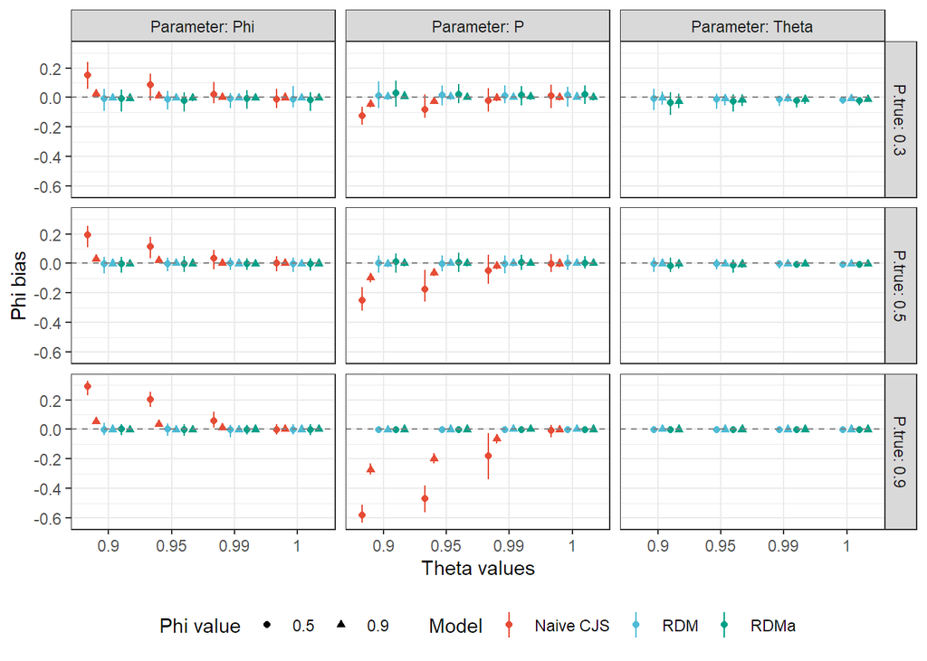

```r
p.bias <- ggplot(data = Res_long, aes(x=factor(Theta.true),
               color=as.factor(Model),  group=1)) +
         xlab('Theta values') +
         ylab('Phi bias') +
         geom_linerange(aes(x= factor(Theta.true), ymin=bias.lci,  ymax=bias.uci),
                        position=position_dodge2(width=0.8)) +
         geom_point(aes(x= factor(Theta.true), y=bias.median,  shape = factor(Phi.true)),
                        position=position_dodge2(width=0.8), size=1.5) +
         facet_grid( P.true ~ Parameter ,labeller = labeller(.rows = label_both, .cols = label_both)) +
         geom_hline( aes(yintercept = 0),  colour = grey(0.5), linetype='dashed') +
         theme_bw()+
         scale_shape(name= 'Phi value') +
         scale_color_npg(name='Model',
            breaks=c('CJS_naive', 'CJSm_ccc_multinom', 'CJSm_ccc_multinom_approx'),
            labels=c('Naive CJS', 'RDM', 'RDMa')) +
         theme(legend.position = "bottom")

p.bias
```

```r
ggsave("bias_25_year.pdf", width = 20, height = 20, units = "cm", dpi=600)
```

### 1.5 Make Figure 2

This figure is somewhat similat to the previous one, but uses simulations where animals were marked only at the first occasion.

First we load result files and format data

```r
out_all<-readRDS('./results/Sim_results_one_cohort.RDS')

# ok, now I want to combine these
library(tidyr)
library(dplyr)

Res <- out_all %>%
       rename(Phi.estimate = Phi.mean, P.estimate = P.mean, Theta.estimate = Theta.mean) %>%
       filter(Converged & N.marked !=100 & !(Model %in% c('CJS','CJS_no_misr') & is.na(Theta.true))) %>%
       group_by(Model, Phi.true, P.true,  N.marked, Theta.true) %>%
       group_modify(~ head(.x, 100)) %>%
       summarize(Phi.mean=mean(Phi.estimate),
          Phi.lci =  quantile(Phi.estimate, 0.025),
          Phi.uci =  quantile(Phi.estimate, 0.975),
          Phi.median =   quantile(Phi.estimate, 0.5),
          Phi.bias.mean = mean(Phi.estimate) - unique(Phi.true),
          Phi.bias.median = median(Phi.estimate) - unique(Phi.true),
          Phi.bias.uci = quantile(Phi.estimate, 0.975) - unique(Phi.true),
          Phi.bias.lci = quantile(Phi.estimate, 0.025) - unique(Phi.true),
          Phi.sc.MSE =  sum((Phi.estimate-unique(Phi.true))^2)/((n())-1)*unique(Phi.true)^2,
          Phi.CI.width= quantile(Phi.estimate, 0.975)-quantile(Phi.estimate, 0.025),
          Phi.CI.coverage= sum(Phi.CI.coverage)/n(),
          Phi.mean.n.eff=mean(Phi.n.eff),
          P.mean=mean(P.estimate),
          P.lci = quantile(P.estimate, 0.025),
          P.uci = quantile(P.estimate, 0.975),
          P.median = quantile(P.estimate, 0.5),
          P.bias.mean = mean(P.estimate) - unique(P.true),
          P.bias.median = median(P.estimate) - unique(P.true),
          P.bias.uci = quantile(P.estimate, 0.975) - unique(P.true),
          P.bias.lci = quantile(P.estimate, 0.025) - unique(P.true),
          P.sc.MSE =  sum((P.estimate-unique(P.true))^2)/((n())-1)*unique(P.true)^2,
          P.CI.width= quantile(P.estimate, 0.975)-quantile(P.estimate, 0.025),
          P.CI.coverage= sum(P.CI.coverage)/n(),
          P.mean.n.eff=mean(P.n.eff),
          Theta.mean=mean(Theta.estimate) ,
          Theta.lci = quantile(Theta.estimate, 0.025, na.rm=TRUE),
          Theta.uci = quantile(Theta.estimate, 0.975, na.rm=TRUE),
          Theta.median = quantile(Theta.estimate, 0.5, na.rm=TRUE),
          Theta.bias.mean = mean(Theta.estimate) - unique(Theta.true),
          Theta.bias.median = median(Theta.estimate) - unique(Theta.true),
          Theta.bias.uci = quantile(Theta.estimate, 0.975, na.rm=TRUE) - unique(Theta.true),
          Theta.bias.lci = quantile(Theta.estimate, 0.025, na.rm=TRUE) - unique(Theta.true),
          Theta.sc.MSE =  sum((Theta.mean-unique(Theta.true))^2)/((n())-1)*unique(Theta.true)^2,
          Theta.CI.width= quantile(Theta.estimate, 0.975, na.rm=TRUE)-quantile(Theta.estimate, 0.025, na.rm=TRUE),
          Theta.CI.coverage= sum(Theta.CI.coverage)/n(),
          Theta.mean.n.eff=mean(Theta.n.eff),
          N_models=n()) %>%
          as.data.frame()
```

and now plot the results

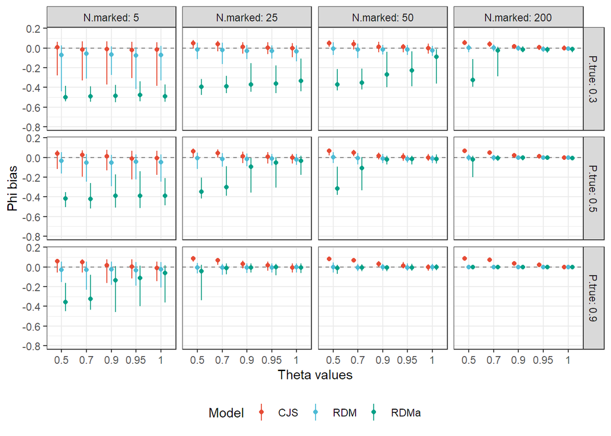

```r
library(ggplot2)
Ylim<-range(c(Res$Phi.bias.median, Res$P.bias.median, Res$Theta.bias.median), na.rm=TRUE)

p.Phi.bias <- ggplot(data = Res, aes(x=factor(Theta.true),
               color=as.factor(Model),  group=1)) +
         xlab('Theta values') +
         ylab('Phi bias') +
         ylim(Ylim) +
         geom_hline( aes(yintercept = 0),  colour = grey(0.5), linetype='dashed') +
         geom_linerange(aes(x= factor(Theta.true), ymin=Phi.bias.lci,  ymax=Phi.bias.uci), position=position_dodge2(width=0.5)) +
         geom_point(aes(x= factor(Theta.true), y=Phi.bias.median), position=position_dodge2(width=0.5)) +
         facet_grid( P.true ~ N.marked ,labeller = labeller(.rows = label_both, .cols = label_both)) +
         theme_bw() +
         scale_color_npg(name='Model',
                         breaks=c('CJS', 'RDM', 'RDMa'),
                         labels=c('CJS', 'RDM', 'RDMa')) +
         theme(legend.position = "bottom")

p.Phi.bias
```

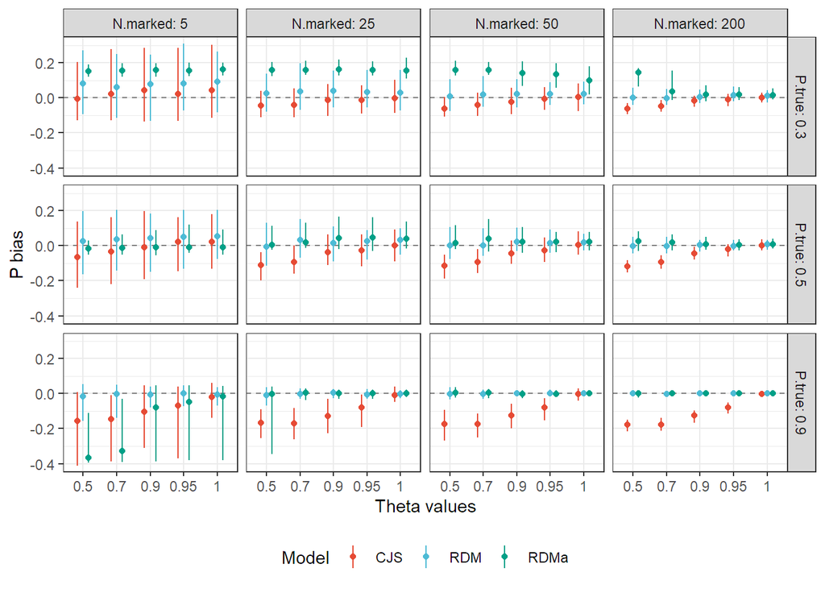

```r
ggsave("Phi_10_years.pdf", width = 20, height = 10, units = "cm", dpi=600)

p.P.bias <- ggplot(data = Res, aes(x=factor(Theta.true),
               color=as.factor(Model),  group=1)) +
         xlab('Theta values') +
         ylab('P bias') +
         geom_hline( aes(yintercept = 0),  colour = grey(0.5), linetype='dashed') +
         geom_linerange(aes(x= factor(Theta.true), ymin=P.bias.lci,  ymax=P.bias.uci), position=position_dodge2(width=0.5)) +
         geom_point(aes(x= factor(Theta.true), y=P.bias.median), position=position_dodge2(width=0.5)) +
         facet_grid( P.true ~ N.marked ,labeller = labeller(.rows = label_both, .cols = label_both)) +
         theme_bw() +
         scale_color_npg(name='Model',
                         breaks=c('CJS', 'RDM', 'RDMa'),
                         labels=c('CJS', 'RDM', 'RDMa')) +
         theme(legend.position = "bottom")


p.P.bias
```

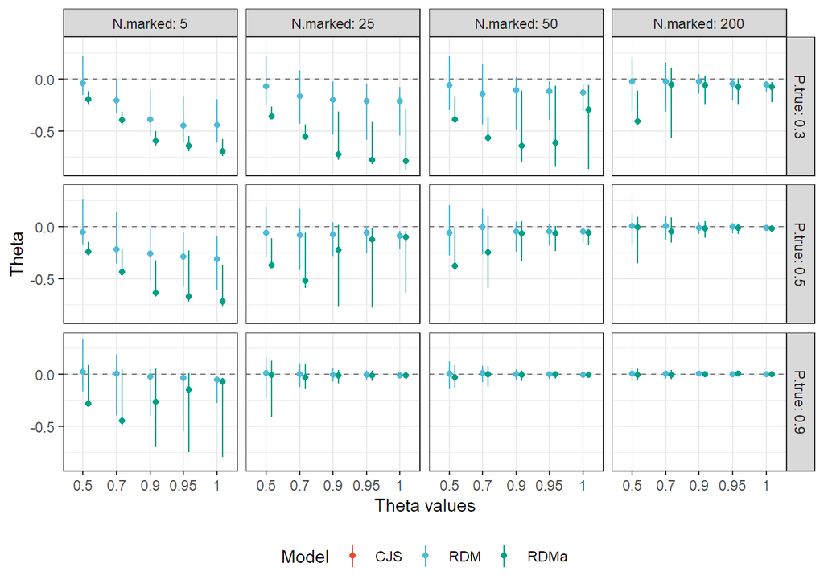

```r
ggsave("P_10_years.pdf", width = 20, height = 10, units = "cm", dpi=600)

p.Theta.bias <- ggplot(data = Res, aes(x=factor(Theta.true),
               color=as.factor(Model),  group=1)) +
         xlab('Theta values') +
         ylab('Theta') +
         geom_hline( aes(yintercept = 0),  colour = grey(0.5), linetype='dashed') +
         geom_linerange(aes(x= factor(Theta.true), ymin=Theta.bias.lci,  ymax=Theta.bias.uci),
                     position=position_dodge2(width=0.5)) +
         geom_point(aes(x= factor(Theta.true), y=Theta.bias.median), position=position_dodge2(width=0.5)) +
         facet_grid( P.true ~ N.marked ,labeller = labeller(.rows = label_both, .cols = label_both)) +
         theme_bw() +
         scale_color_npg(name='Model',
                         breaks=c('CJS', 'RDM', 'RDMa'),
                         labels=c('CJS', 'RDM', 'RDMa')) +
         theme(legend.position = "bottom")

p.Theta.bias
```

```r
ggsave("Theta_10_years.pdf", width = 20, height = 10, units = "cm", dpi=600)
```

## 2. Estimation of trend in survival probability over time

In this part we simulate data with no trend in survival over time and then run CJS, RDM and RDMa with Time trend

## 2.1 wrapper function to run the models

```r
run_T_c_c_models<-function(CH, n.chains=6,  n.adapt=NULL, RHat_limit=1.1,
             max.iter=200000, iter.increment=5000, models.to.run=c('CJS', 'RDM', 'RDMa')) {
  # this function runs Phi_dot_p_dot_Theta_dot models
  Res<-list(CH=CH)

  if ('CJS' %in% models.to.run) {
     cat('running CJS-T-c model')
     # flatten the data
     CH_flat<-apply(CH, c(1,2), sign)
     # Create vector with occasion of marking
     f <- apply(CH_flat, 1, get.first)
     Order<-(order(f))
     CH_flat<-CH_flat[Order,]
     f<-f[Order]
     # Specify model in BUGS language
     sink("cjs-T-c.jags")
     cat("
       model {
   # Priors and constraints
   for (i in 1:nind){
      for (t in f[i]:(n.occasions-1)){
         logit(phi[i,t]) <- phi.mu+phi.beta*t #intercept and slope for survival
         p[i,t] <- mean.p
      } #t
   } #i

   phi.mu ~ dnorm(0,0.1)          # Prior for intercept in survival
   phi.beta ~ dnorm(0,10)          # Prior for slope in survival
   mean.p ~ dunif(0, 1)           # Prior for mean recapture

   # estimate mean phi
   logit(mean.phi)<-phi.mu+phi.beta*(n.occasions/2)

         # Likelihood
         for (i in 1:nind){
           # Define latent state at first capture
           z[i,f[i]] <- 1
           for (t in (f[i]+1):n.occasions){
             # State process
             z[i,t] ~ dbern(mu1[i,t])
             mu1[i,t] <- phi[i,t-1] * z[i,t-1]
             # Observation process
             y[i,t] ~ dbern(mu2[i,t])
             mu2[i,t] <- p[i,t-1] * z[i,t]
           } #t
         } #i
      }
    ",fill = TRUE)
    sink()

    # Bundle data
    jags.data <- list(y = CH_flat, f = f, nind = dim(CH_flat)[1],
                      n.occasions = dim(CH_flat)[2])

    inits <- function(){list(phi.mu = rnorm(1, 0,1),
                         phi.beta = rnorm(1, 0,0.5),
                         mean.p = runif(1, 0.5,1),
                         z = known.state.cjs(CH_flat))}

   # Parameters monitored
    parameters <- c("mean.p", "mean.phi", "phi.mu", "phi.beta")

    # Call JAGS from R
    cjs.T.c <- autojags(jags.data, inits,
                       parameters, "cjs-T-c.jags", n.chains = n.chains,
                       parallel=TRUE,
                       Rhat.limit=RHat_limit, n.adapt=NULL,
                       max.iter=max.iter, iter.increment= iter.increment, save.all.iter=FALSE)
    cat('   Done!\n')
    Res$CJS<-cjs.T.c
  }
  if ('RDM' %in% models.to.run | 'RDMa' %in% models.to.run) {
    # Create vector with occasion of marking
    f <- apply(CH, 1, get.first)
    Order<-(order(f))
    CH<-CH[Order,]
    f<-f[Order]

    sightings_and_fresh<-colSums(CH) # count per year
    All.Years=data.frame(Years=1:dim(CH)[2], N_marked=0)
    Rle<-rle(apply(CH, 1, get.first))
    for (year in 1:length(Rle$lengths)) {
      All.Years$N_marked[Rle$values[year]]<-Rle$lengths[year]
    }

    N_marked<-  All.Years$N_marked
    N_reads<-sightings_and_fresh-N_marked
    N_reads<-N_reads[-1]
    sum_N_marks_used<-cumsum(All.Years$N_marked)

    # Bundle data
    jags.data <- list(y = CH, f = f, nind = dim(CH)[1],
                     n.occasions = dim(CH)[2],
                     sum_N_marks_used=sum_N_marks_used,
                     N_reads=N_reads, N_reads2=N_reads)

    inits <- function(){list(phi.mu = rnorm(1, 0,1),
                         phi.beta = rnorm(1, 0,0.5),
                         mean.p = runif(1, 0.5,1),
                         z = known.state.cjs.mult(CH),
                         mean.theta=runif(1, 0.5, 1))}

    # Parameters monitored
    parameters <- c("mean.phi", "phi.mu", "phi.beta" , "mean.p", "mean.theta")
  }

   if ('RDM' %in% models.to.run) {
    # Specify model in BUGS language
    sink("RDM-T-c-c.jags")
    cat("
    model {
    # Priors and constraints
    for (i in 1:nind){
       for (t in f[i]:(n.occasions-1)){
          logit(phi[i,t]) <- phi.mu+phi.beta*t
          lambda_true[i,t]<-mean.lambda.true
       } #t
    } #i
    phi.mu ~ dnorm(0,1)          # Prior for intercept in survival
    phi.beta ~ dnorm(0,10)         # Prior for slope in survival
    mean.p ~ dunif(0.5, 1)           # Prior for mean recapture
    mean.lambda.true<- -log(1-mean.p)
    mean.theta ~ dunif(0.5,1)        # Prior for mean correct identification
    for (t in 1:(n.occasions-1)) {
    theta.t[t]<-mean.theta
  }

    # estimate mean phi
    logit(mean.phi)<-phi.mu+phi.beta*(n.occasions/2)


        # Likelihood
        for (i in 1:nind){
          # Define latent state at first capture
          z[i,f[i]] <- 1
          for (t in (f[i]+1):n.occasions){
            # State process
            z[i,t] ~ dbern(mu1[i,t])
            mu1[i,t] <- phi[i,t-1] * z[i,t-1]
            # Observation process
            lambda_obs[i,t-1]<- lambda_true[i,t-1]*z[i,t]*theta.t[t-1]+
                        Lambda_z_sum[t-1] -
                        lambda_true[i,t-1]*z[i,t]*(1-theta.t[t-1])/(sum_N_marks_used[t-1]-1)
          } #t
        } #i

        for (t in 1:(n.occasions-1)) {
        # here I add the total sum over all lambda_z
        Lambda_z_sum[t]<-sum(lambda_true[1:(sum_N_marks_used[t]),t]*
                   z[1:(sum_N_marks_used[t]),t+1])*
                   (1-theta.t[t])/(sum_N_marks_used[t]-1)
        # Below is the same but in RDMa model
        #Lambda_z_sum[t]<-N_reads2[t]*
        #     (1-theta.t[t])/(sum_N_marks_used[t]-1)
        Lambda_obs_sum[t]<-sum(lambda_obs[1:(sum_N_marks_used[t]),t])
        P_multin[1:(sum_N_marks_used[t]),t] <-
              lambda_obs[1:(sum_N_marks_used[t]),t]/
              ifelse(Lambda_obs_sum[t]==0, 1, Lambda_obs_sum[t])
        N_reads[t]~ dpois(Lambda_obs_sum[t])
        y[1:sum_N_marks_used[t],t+1] ~
              dmulti(P_multin[1:sum_N_marks_used[t],t],
              N_reads2[t])
        }
    }
    ",fill = TRUE)
    sink()

    # Call JAGS from R
    RDM.T.c.c <- autojags(jags.data, inits, parameters,
                       "RDM-T-c-c.jags", n.chains = n.chains,
                       parallel=TRUE,
                       Rhat.limit=RHat_limit, n.adapt=NULL,
                       max.iter=max.iter, iter.increment= iter.increment, save.all.iter=FALSE)
                       cat('   Done!\n')
    Res$RDM<-RDM.T.c.c
  }

  if ('RDMa' %in% models.to.run) {
    cat('running RDMa-T-c-c model')
    # Specify model in BUGS language
    sink("RDMa-T-c-c.jags")
    cat("
    model {
    # Priors and constraints
    for (i in 1:nind){
       for (t in f[i]:(n.occasions-1)){
          logit(phi[i,t]) <- phi.mu+phi.beta*t
          lambda_true[i,t]<-mean.lambda.true
       } #t
    } #i
    phi.mu ~ dnorm(0,1)          # Prior for intercept in survival
    phi.beta ~ dnorm(0,10)         # Prior for slope in survival
    mean.p ~ dunif(0.5, 1)           # Prior for mean recapture
    mean.lambda.true<- -log(1-mean.p)
    mean.theta ~ dunif(0.5,1)        # Prior for mean correct identification
    for (t in 1:(n.occasions-1)) {
    theta.t[t]<-mean.theta
    }

    # estimate mean phi
    logit(mean.phi)<-phi.mu+phi.beta*(n.occasions/2)

        # Likelihood
        for (i in 1:nind){
          # Define latent state at first capture
          z[i,f[i]] <- 1
          for (t in (f[i]+1):n.occasions){
            # State process
            z[i,t] ~ dbern(mu1[i,t])
            mu1[i,t] <- phi[i,t-1] * z[i,t-1]
            # Observation process
            lambda_obs[i,t-1]<- lambda_true[i,t-1]*z[i,t]*theta.t[t-1]+
                          Lambda_z_sum[t-1] -
                          lambda_true[i,t-1]*z[i,t]*(1-theta.t[t-1])/(sum_N_marks_used[t-1]-1)
          } #t
        } #i

        for (t in 1:(n.occasions-1)) {
        # here I add the total sum over all lambda_z
        #Lambda_z_sum[t]<-sum(lambda_true[1:(sum_N_marks_used[t]),t]*
        #           z[1:(sum_N_marks_used[t]),t+1])*
        #          (1-theta.t[t])/(sum_N_marks_used[t]-1)
        # above is the RDM model
        Lambda_z_sum[t]<-N_reads2[t]*
              (1-theta.t[t])/(sum_N_marks_used[t]-1)
        Lambda_obs_sum[t]<-sum(lambda_obs[1:(sum_N_marks_used[t]),t])
        P_multin[1:(sum_N_marks_used[t]),t] <-
              lambda_obs[1:(sum_N_marks_used[t]),t]/
              ifelse(Lambda_obs_sum[t]==0, 1, Lambda_obs_sum[t])
        N_reads[t]~ dpois(Lambda_obs_sum[t])
        y[1:sum_N_marks_used[t],t+1] ~
              dmulti(P_multin[1:sum_N_marks_used[t],t],
              N_reads2[t])
        }
    }
    ",fill = TRUE)
    sink()

    # Call JAGS from R
    RDMa.T.c.c <- autojags(jags.data, inits, parameters,
                       "RDMa-T-c-c.jags", n.chains = n.chains,
                       parallel=TRUE,
                       Rhat.limit=RHat_limit, n.adapt=NULL,
                       max.iter=max.iter, iter.increment= iter.increment, save.all.iter=FALSE)
                       cat('   Done!\n')
    Res$RDMa<-RDMa.T.c.c
   }
   return(Res)
}
```

### 2.1 define simulation parameters

#### Define parameter values

```r
n.occasions <- 25                   # Number of capture occasions
marked <- rep(25, n.occasions-1)   # Annual number of newly marked individuals
phi <- rep(0.7, n.occasions-1) # survival
p <- rep(0.9, n.occasions-1)  # resighting
theta<- rep(0.95, n.occasions-1) # correctly identified
```

#### Define matrices with survival recapture and correct identification

```r
PHI <- matrix(phi, ncol = n.occasions-1, nrow = sum(marked))
P <- matrix(p, ncol = n.occasions-1, nrow = sum(marked))
THETA<-matrix(theta, ncol = n.occasions-1, nrow = sum(marked))

RHat_limit=1.01
max.iter=8000
n.adapt=4000
iter.increment=4000
nRuns=5
```